# Тестовое задание для аналитика данных

**Описание задачи:**  
Вам предоставлены данные по 25 сотрудникам агентства недвижимости за последний месяц. Ваша задача — проанализировать данные, выявить закономерности, сделать выводы и предложить рекомендации для улучшения показателей.

Данные для анализа:  
Каждый сотрудник представлен следующими показателями:

1. Количество звонков (исходящих).
2. Количество SMS (отправленных клиентам).
3. Количество встреч с клиентами.
4. Количество выставленных листингов (объектов недвижимости).
5. Количество подписанных договоров с клиентами.
6. Количество эксклюзивных договоров.
7. Количество полученных авансов.
8. Количество завершенных сделок.
9. Среднее время обработки звонка (в минутах).
10. Среднее время подготовки листинга (в часах).
11. Среднее время между встречей и подписанием договора (в днях).
12. Средний размер аванса (в рублях).
13. Средний размер комиссии за сделку (в рублях).
14. Процент завершенных сделок от общего числа договоров.
15. Процент эксклюзивных договоров от общего числа договоров.

**Задания:**

*1. Анализ данных:*  
• Проведите описательный анализ данных (средние значения, медианы, стандартные отклонения и т.д.).  
• Постройте графики и диаграммы для визуализации ключевых показателей (например, распределение количества звонков, сделок, авансов и т.д.).  
• Выявите топ-5 сотрудников по количеству завершенных сделок и по размеру комиссии.  
• Определите сотрудников с самыми низкими показателями по количеству встреч и подписанных договоров.  
*2. Выявление закономерностей:*  
• Найдите корреляцию между количеством звонков и количеством встреч.  
• Определите, есть ли связь между количеством SMS и количеством подписанных договоров.  
• Проверьте, влияет ли среднее время подготовки листинга на количество завершенных сделок.  
• Проанализируйте, как размер аванса влияет на вероятность завершения сделки.  
*3. Формирование выводов:*  
• Какие показатели наиболее сильно влияют на количество завершенных сделок?  
• Какие сотрудники демонстрируют наилучшие результаты и почему?  
• Какие сотрудники нуждаются в дополнительном обучении или поддержке?  
• Какие процессы можно оптимизировать для повышения эффективности работы команды?  
*4. Рекомендации:*  
• Предложите меры для увеличения количества встреч и подписанных договоров.  
• Дайте рекомендации по улучшению показателей сотрудников с низкой эффективностью.  
• Предложите способы сокращения времени между встречей и подписанием договора.  
• Опишите, как можно увеличить количество эксклюзивных договоров и авансов.

**Форма представления результатов:**

*Отчет в формате `PDF` или `PowerPoint`, содержащий:*  
• Описание данных и методов анализа.  
• Графики и диаграммы.  
• Основные выводы.  
• Рекомендации для улучшения показателей.

## Общая информация.

```python
# Загрузка библиотек
import pandas as pd
import numpy as np
import matplotlib.pyplot as plt
import seaborn as sns
import phik
```

### Считываем данные из excel-файла в датафрейм и сохраняем в переменную df.

```python
df = pd.read_excel('Данные для тестового задания (1).xlsx', header=2)
df = df.drop(df.columns[0], axis=1)
```

### Выводим 5 верхних строк таблицы на экран.

```python
df.head()
```

|  | Сотрудник | Звонки | SMS | Встречи | Листинги | Договора | Эксклюзивы | Авансы | Сделки | Среднее время обработки звонка (мин) | Среднее время подготовки листинга (часы) | Среднее время между встречей и подписанием договора (дни) | Средний размер аванса (руб) | Средний размер комиссии за сделку (руб) | Процент завершенных сделок от общего числа договоров | Процент эксклюзивных договоров от общего числа договоров |
| --- | --- | --- | --- | --- | --- | --- | --- | --- | --- | --- | --- | --- | --- | --- | --- | --- |
| 0 | Иванов А.А. | 120 | 50 | 15 | 10 | 8 | 3 | 5 | 4 | 5.2 | 3.5 | 7 | 50000 | 120000 | 0.500000 | 0.375000 |
| 1 | Петрова В.С. | 90 | 30 | 10 | 7 | 5 | 2 | 3 | 3 | 4.8 | 4.0 | 5 | 45000 | 110000 | 0.600000 | 0.400000 |
| 2 | Сидоров Д.И. | 150 | 60 | 20 | 12 | 10 | 4 | 6 | 5 | 6.0 | 3.0 | 6 | 60000 | 130000 | 0.500000 | 0.400000 |
| 3 | Кузнецова Е.П. | 80 | 25 | 8 | 6 | 4 | 1 | 2 | 2 | 5.5 | 3.8 | 8 | 55000 | 125000 | 0.500000 | 0.250000 |
| 4 | Васильев М.К. | 200 | 70 | 25 | 15 | 12 | 5 | 8 | 7 | 4.5 | 4.5 | 4 | 40000 | 100000 | 0.583333 | 0.416667 |

**Замечание:** Для удобства сократим названия части колонок.

```python
df.rename(columns={"Среднее время обработки звонка (мин)": "Ср. звонки (мин)",
                   "Среднее время подготовки листинга (часы)": "Ср. листинг (часы)",
                   "Среднее время между встречей и подписанием договора (дни)": "Ср. встреча-договор (дни)",
                   "Средний размер аванса (руб)": "Ср. аванс (руб)",
                   "Средний размер комиссии за сделку (руб)": "Ср. комиссия (руб)",
                   "Процент завершенных сделок от общего числа договоров ": "% сделок от договоров",
                   "Процент эксклюзивных договоров от общего числа договоров": "% экскл. договоров от общ. договоров"},
                   inplace=True)
```

Описание данных:

1. `Сотрудник` - ФИО сотрудника
2. `Звонки` - Количество звонков (исходящих)
3. `SMS`- Количество SMS (отправленных клиентам)
4. `Встречи` - Количество встреч с клиентами
5. `Листинги` - Количество выставленных листингов (объектов недвижимости)
6. `Договора` - Количество подписанных договоров с клиентами
7. `Эксклюзивы` - Количество эксклюзивных договоров
8. `Авансы` - Количество полученных авансов
9. `Сделки` - Количество завершенных сделок
10. `Ср. звонки (мин)` - Среднее время обработки звонка (мин)
11. `Ср. листинг (часы)` - Среднее время подготовки листинга (часы)
12. `Ср. встреча-договор (дни)` - Среднее время между встречей и подписанием договора (дни)
13. `Ср. аванс (руб)` - Средний размер аванса (руб)
14. `Ср. комиссия (руб)` - Средний размер комиссии за сделку (руб)
15. `"% сделок от договоров` - Процент завершенных сделок от общего числа договоров
16. `"% экскл. договоров от общ. договоров"` - Процент эксклюзивных договоров от общего числа договоров

```python
# Вывод информации о данных
df.info()
```

```
<class 'pandas.core.frame.DataFrame'>
RangeIndex: 25 entries, 0 to 24
Data columns (total 16 columns):
 #   Column                                Non-Null Count  Dtype
---  ------                                --------------  -----
 0   Сотрудник                             25 non-null     object
 1   Звонки                                25 non-null     int64
 2   SMS                                   25 non-null     int64
 3   Встречи                               25 non-null     int64
 4   Листинги                              25 non-null     int64
 5   Договора                              25 non-null     int64
 6   Эксклюзивы                            25 non-null     int64
 7   Авансы                                25 non-null     int64
 8   Сделки                                25 non-null     int64
 9   Ср. звонки (мин)                      25 non-null     float64
 10  Ср. листинг (часы)                    25 non-null     float64
 11  Ср. встреча-договор (дни)             25 non-null     int64
 12  Ср. аванс (руб)                       25 non-null     int64
 13  Ср. комиссия (руб)                    25 non-null     int64
 14  % сделок от договоров                 25 non-null     float64
 15  % экскл. договоров от общ. договоров  25 non-null     float64
dtypes: float64(4), int64(11), object(1)
memory usage: 3.2+ KB
```

**Замечание:** Все типы данных соответствуют, пропусков данных нет.

### Проверим датафрейм на наличие явных дубликатов.

```python
df.duplicated().sum()
```

```
0
```

**Замечание:** Дубликатов не обнаружено.

## Анализ данных.

### Выводим информацию о датафрейме с помощью метода `describe()`.

```python
df.describe()
```

|  | Звонки | SMS | Встречи | Листинги | Договора | Эксклюзивы | Авансы | Сделки | Ср. звонки (мин) | Ср. листинг (часы) | Ср. встреча-договор (дни) | Ср. аванс (руб) | Ср. комиссия (руб) | % сделок от договоров | % экскл. договоров от общ. договоров |
| --- | --- | --- | --- | --- | --- | --- | --- | --- | --- | --- | --- | --- | --- | --- | --- |
| count | 25.000000 | 25.000000 | 25.00000 | 25.00000 | 25.000000 | 25.000000 | 25.00 | 25.000000 | 25.000000 | 25.000000 | 25.000000 | 25.000000 | 25.000000 | 25.000000 | 25.000000 |
| mean | 121.040000 | 45.680000 | 14.60000 | 9.60000 | 7.360000 | 3.000000 | 4.44 | 4.000000 | 5.288000 | 3.724000 | 6.440000 | 51600.000000 | 119680.000000 | 0.538089 | 0.385911 |
| std | 38.692678 | 16.100518 | 6.35741 | 3.62859 | 3.212994 | 1.554563 | 2.20 | 1.802776 | 0.510163 | 0.397157 | 1.583246 | 5825.590099 | 11721.490235 | 0.067214 | 0.106552 |
| min | 65.000000 | 18.000000 | 4.00000 | 3.00000 | 2.000000 | 0.000000 | 1.00 | 1.000000 | 4.500000 | 3.000000 | 4.000000 | 40000.000000 | 100000.000000 | 0.333333 | 0.000000 |
| 25% | 90.000000 | 32.000000 | 9.00000 | 7.00000 | 5.000000 | 2.000000 | 3.00 | 3.000000 | 4.900000 | 3.400000 | 5.000000 | 47500.000000 | 110000.000000 | 0.500000 | 0.375000 |
| 50% | 115.000000 | 48.000000 | 15.00000 | 10.00000 | 8.000000 | 3.000000 | 5.00 | 4.000000 | 5.200000 | 3.700000 | 6.000000 | 52000.000000 | 120000.000000 | 0.545455 | 0.400000 |
| 75% | 145.000000 | 59.000000 | 20.00000 | 13.00000 | 10.000000 | 4.000000 | 6.00 | 5.000000 | 5.700000 | 4.000000 | 8.000000 | 56000.000000 | 129000.000000 | 0.583333 | 0.444444 |
| max | 200.000000 | 70.000000 | 25.00000 | 15.00000 | 12.000000 | 5.000000 | 8.00 | 7.000000 | 6.200000 | 4.500000 | 9.000000 | 60500.000000 | 140000.000000 | 0.666667 | 0.500000 |

**Замечание:** Здесь можно увидеть информацию о входных данных по столбцам (например максимальное и минимальное значение признака, стандартное отклонение, среднее и медианы - 50%).

### Построим общую гистограмму для всех числовых столбцов таблицы.

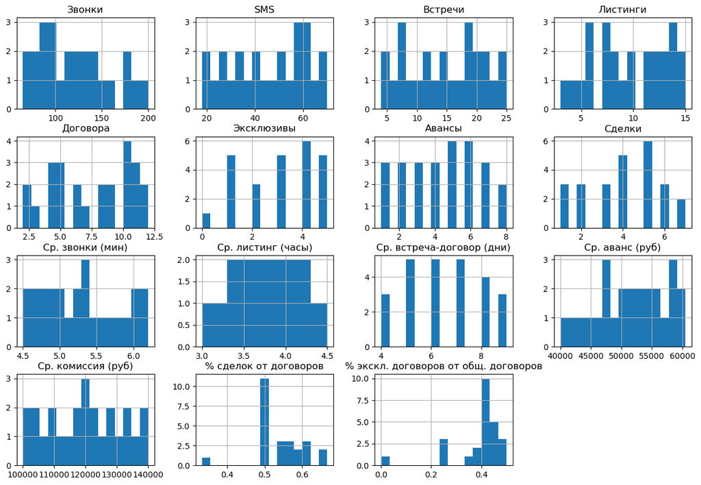

```python
df.hist(figsize=(15,10), bins=15);
```

**Замечание:** Гистограммы наглядно представляют как распределяются значения в столбцах.

### Выявим топ-5 сотрудников по количеству завершенных сделок и по размеру комиссии.

```python
# Вывод топ-5 сотрудников по количеству заключенных сделок
df.sort_values(by='Сделки', ascending=False)[['Сотрудник', 'Сделки']][:5]
```

|  | Сотрудник | Сделки |
| --- | --- | --- |
| 4 | Васильев М.К. | 7 |
| 16 | Дмитриев В.Р. | 7 |
| 13 | Борисова А.К. | 6 |
| 20 | Тарасов И.Н. | 6 |
| 8 | Павлов А.Н. | 6 |

```python
# Проверка 6 по количеству сделок сотрудника
df.sort_values(by='Сделки', ascending=False)[['Сотрудник', 'Сделки']][5:6]
```

|  | Сотрудник | Сделки |
| --- | --- | --- |
| 24 | Гусев Д.М. | 5 |

**Замечание:** Шестой по рангу сотрудник совершил меньше сделок чем пятый, значит только первые пять сотрудников заключили больше всех сделок.

```python
# Вывод топ-5 сотрудников по размеру комиссии
df.sort_values(by='Ср. комиссия (руб)', ascending=False)[['Сотрудник', 'Ср. комиссия (руб)']][:5]
```

|  | Сотрудник | Ср. комиссия (руб) |
| --- | --- | --- |
| 21 | Захарова Е.А. | 140000 |
| 15 | Федорова Н.И. | 138000 |
| 6 | Морозов И.В. | 135000 |
| 18 | Киселев А.Д. | 134000 |
| 12 | Григорьев П.С. | 132000 |

```python
# Проверка 6 по размеру комиссии сотрудника
df.sort_values(by='Ср. комиссия (руб)', ascending=False)[['Сотрудник', 'Ср. комиссия (руб)']][5:6]
```

|  | Сотрудник | Ср. комиссия (руб) |
| --- | --- | --- |
| 2 | Сидоров Д.И. | 130000 |

**Замечание:** Шестой по рангу сотрудник получал меньшую комиссию чем пятый, значит только первые пять сотрудников имели наибольшую комиссию.  
Заметим также что сотрудники в этих списках отличаются.

### Определим сотрудников с самыми низкими показателями по количеству встреч и подписанных договоров.

```python
# Вывод 5 сотрудников с самым низким количеством встреч
df.sort_values(by='Встречи', ascending=True)[['Сотрудник', 'Встречи']].head(5)
```

|  | Сотрудник | Встречи |
| --- | --- | --- |
| 19 | Антонова Л.С. | 4 |
| 15 | Федорова Н.И. | 5 |
| 7 | Семенова Т.Д. | 6 |
| 12 | Григорьев П.С. | 7 |
| 3 | Кузнецова Е.П. | 8 |

```python
# Вывод 5 сотрудников с самым низким количеством подписанных договоров
df.sort_values(by='Договора', ascending=True)[['Сотрудник', 'Договора']].head(5)
```

|  | Сотрудник | Договора |
| --- | --- | --- |
| 19 | Антонова Л.С. | 2 |
| 15 | Федорова Н.И. | 2 |
| 7 | Семенова Т.Д. | 3 |
| 12 | Григорьев П.С. | 4 |
| 3 | Кузнецова Е.П. | 4 |

**Замечание:** Сотрудники с самыми низкими показателями по количеству встреч и подписанных договоров: `Антонова Л.С.`, `Федорова Н.И.` и `Семенова Т.Д.`

## Выявление закономерностей.

### Найдём корреляцию между количеством звонков и количеством встреч.

```python
# Корреляция между количеством звонков и количеством встреч
df[['Звонки', 'Встречи']].corr()
```

|  | Звонки | Встречи |
| --- | --- | --- |
| Звонки | 1.000000 | 0.974381 |
| Встречи | 0.974381 | 1.000000 |

**Замечание:** Корреляция показывает сильно выраженную линейную связь между количеством звонков и встреч.  
Для наглядности визуализируем эту связь.

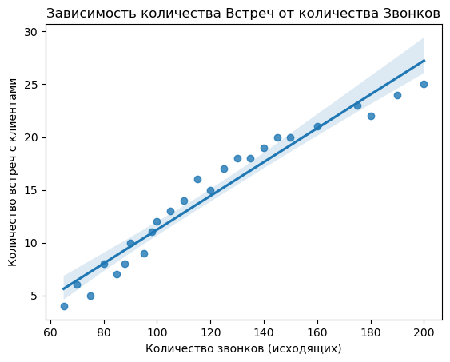

```python
# Построение точечного графика с регрессионной линией
sns.regplot(data=df, x='Звонки', y='Встречи')
plt.title('Зависимость количества Встреч от количества Звонков')
plt.xlabel('Количество звонков (исходящих)')
plt.ylabel('Количество встреч с клиентами');
```

### Определим, есть ли связь между количеством SMS и количеством подписанных договоров.

```python
# Корреляция между количеством SMS и количеством подписанных договоров
df[['SMS', 'Договора']].corr()
```

|  | SMS | Договора |
| --- | --- | --- |
| SMS | 1.000000 | 0.990608 |
| Договора | 0.990608 | 1.000000 |

**Замечание:** Корреляция показывает сильно выраженную линейную связь между количеством SMS и подписанных договоров.  
Для наглядности визуализируем эту связь.

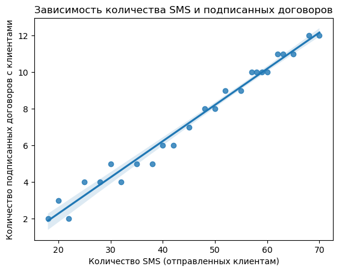

```python
# Построение точечного графика с регрессионной линией
sns.regplot(data=df, x='SMS', y='Договора')
plt.title('Зависимость количества SMS и подписанных договоров')
plt.xlabel('Количество SMS (отправленных клиентам)')
plt.ylabel('Количество подписанных договоров с клиентами');
```

### Проверим, влияет ли среднее время подготовки листинга на количество завершенных сделок.

```python
# Корреляция между средним временем подготовки листинга и количеством завершенных сделок
df[['Ср. листинг (часы)','Сделки']].corr()
```

|  | Ср. листинг (часы) | Сделки |
| --- | --- | --- |
| Ср. листинг (часы) | 1.000000 | -0.069834 |
| Сделки | -0.069834 | 1.000000 |

**Замечание:** Корреляция не показывает средним временем подготовки листинга и количеством завершенных сделок.  
Однако связь между признаками может быть нелинейной. Для анализа визуализируем эту связь.

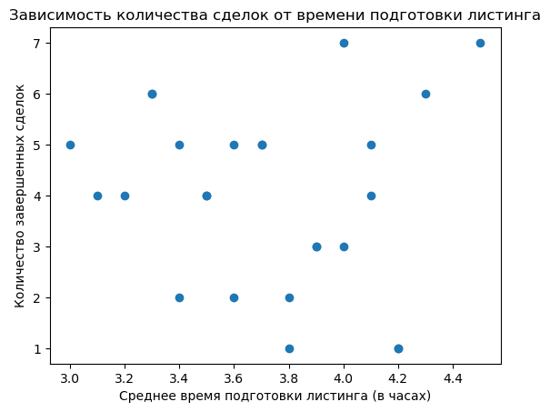

```python
# Построение точечного графика
plt.scatter(df['Ср. листинг (часы)'], df['Сделки'])
plt.title('Зависимость количества сделок от времени подготовки листинга')
plt.xlabel('Среднее время подготовки листинга (в часах)')
plt.ylabel('Количество завершенных сделок');
```

**Замечание:** Здесь мы не можем увидеть мвязи между признаками.  
Однако связь между ними все же может быть. Возможно нам не хватает данных или признаки связаны между собой через какие-либо другие. Например время подготовки листинга влияет на его количество, а количество листингов влияет на количество сделок. И таким образом эти признаки связаны.

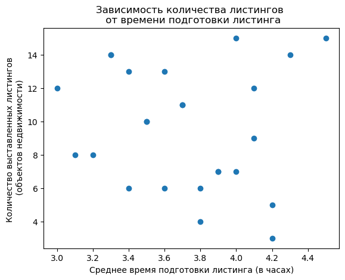

```python
# Построение точечного графика
plt.scatter(df['Ср. листинг (часы)'], df['Листинги'])
plt.title('Зависимость количества листингов \n от времени подготовки листинга')
plt.xlabel('Среднее время подготовки листинга (в часах)')
plt.ylabel('Количество выставленных листингов \n (объектов недвижимости)');
```

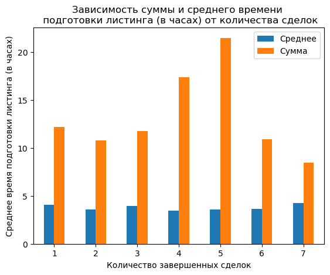

```python
# Построение графиков зависимости суммы и среднего времени подготовки листинга (в часах) от количества сделок
pd.DataFrame(df.groupby('Сделки')['Ср. листинг (часы)'].agg(['mean', 'sum'])).plot(kind='bar')
plt.xticks(rotation=0)
plt.legend(['Среднее', 'Сумма'])
plt.title('Зависимость суммы и среднего времени \n подготовки листинга (в часах) от количества сделок')
plt.xlabel('Количество завершенных сделок')
plt.ylabel('Среднее время подготовки листинга (в часах)');
```

**Замечание:** В данном случае связь выявить не удалось. Однако одназначно утверждать это преждевременно. Признаки могут быть связаны другим способом.

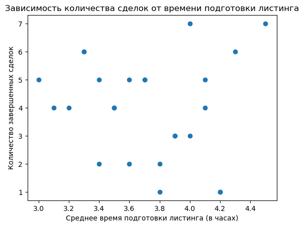

```python
# Построение точечного графика
plt.scatter(df['Ср. листинг (часы)'], df['Сделки'])
plt.title('Зависимость количества сделок от времени подготовки листинга')
plt.xlabel('Среднее время подготовки листинга (в часах)')
plt.ylabel('Количество завершенных сделок');
```

### Проанализируем, как размер аванса влияет на вероятность завершения сделки.

```python
# Корреляция между средним размером аванса и количеством завершенных сделок
df[['Ср. аванс (руб)', 'Сделки']].corr()
```

|  | Ср. аванс (руб) | Сделки |
| --- | --- | --- |
| Ср. аванс (руб) | 1.000000 | -0.182501 |
| Сделки | -0.182501 | 1.000000 |

```python
# Корреляция между средним размером аванса и процентом завершенных сделок от общего числа договоров
df[['Ср. аванс (руб)', '% сделок от договоров']].corr()
```

|  | Ср. аванс (руб) | % сделок от договоров |
| --- | --- | --- |
| Ср. аванс (руб) | 1.000000 | -0.018194 |
| % сделок от договоров | -0.018194 | 1.000000 |

**Замечание:** Корреляция не показывает линейную связь между средним размером аванса и вероятностью завершения сделки. Однако связь между признаками может быть нелинейной. Для анализа визуализируем эту связь.

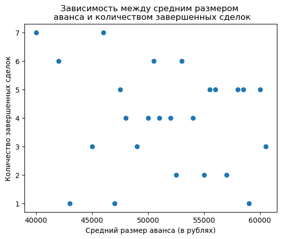

```python
# Построение точечного графика
plt.scatter(df['Ср. аванс (руб)'], df['Сделки'])
plt.title('Зависимость между средним размером \n аванса и количеством завершенных сделок')
plt.xlabel('Средний размер аванса (в рублях)')
plt.ylabel('Количество завершенных сделок');
```

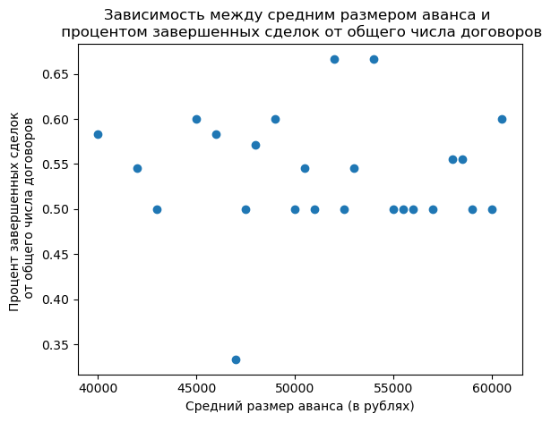

```python
# Построение точечного графика
plt.scatter(df['Ср. аванс (руб)'], df['% сделок от договоров'])
plt.title('Зависимость между средним размером аванса и \n процентом завершенных сделок от общего числа договоров')
plt.xlabel('Средний размер аванса (в рублях)')
plt.ylabel('Процент завершенных сделок \n от общего числа договоров');
```

**Замечание:** Здесь мы не можем увидеть мвязи между признаками.  
Однако связь между ними все же может быть. Возможно нам не хватает данных или признаки связаны между собой через какие-либо другие.

## Формирование выводов.

```python
print("Корреляция количества завершенных сделок с остальными признаками")
print(df.corr()["Сделки"].sort_values(ascending=False))
```

```
Корреляция количества завершенных сделок с остальными признаками
Сделки                                  1.000000
Авансы                                  0.987534
Встречи                                 0.981591
Эксклюзивы                              0.981257
SMS                                     0.979020
Договора                                0.978309
Листинги                                0.974542
Звонки                                  0.959321
% экскл. договоров от общ. договоров    0.545788
% сделок от договоров                   0.372694
Ср. листинг (часы)                     -0.069834
Ср. звонки (мин)                       -0.108730
Ср. встреча-договор (дни)              -0.145982
Ср. аванс (руб)                        -0.182501
Ср. комиссия (руб)                     -0.189293
Name: Сделки, dtype: float64
```

## Рекомендации.

**1. Меры для увеличения количества встреч и подписанных договоров:**

- Увеличение количества звонков:
  - Внедрить систему KPI (ключевых показателей эффективности) для сотрудников, где количество звонков будет одним из ключевых показателей.
  - Провести тренинги по эффективным техникам холодных звонков и активных продаж.
- Улучшение качества звонков:
  - Разработать скрипты для звонков, чтобы сотрудники могли более эффективно привлекать клиентов.
  - Обучить сотрудников навыкам выявления потребностей клиентов и убеждения.
- Автоматизация процесса:
  - Внедрить CRM-систему для автоматизации напоминаний о звонках и встречах.
  - Использовать инструменты для автоматической отправки SMS и email-напоминаний клиентам.
- Мотивация сотрудников:
  - Ввести бонусы за количество проведенных встреч и подписанных договоров.
  - Проводить ежемесячные соревнования между сотрудниками с призами за лучшие результаты.

**2. Рекомендации по улучшению показателей сотрудников с низкой эффективностью:**

- Индивидуальный коучинг:
  - Назначить наставников для сотрудников с низкими показателями.
  - Провести индивидуальные тренинги по продажам и коммуникациям.
- Анализ слабых мест:
  - Провести анализ работы сотрудников с низкой эффективностью, чтобы выявить их слабые стороны (например, недостаток навыков продаж, низкая активность, проблемы с тайм-менеджментом).
- Постановка четких целей:
  - Установить для таких сотрудников конкретные, измеримые и достижимые цели (например, "провести 10 встреч в неделю").
  - Регулярно проводить встречи для обсуждения прогресса.
- Психологическая поддержка:
  - Провести мотивационные тренинги для повышения уверенности в себе.
  - Создать поддерживающую атмосферу в коллективе.

**3. Способы сокращения времени между встречей и подписанием договора:**

- Оптимизация процесса подготовки документов:
  - Упростить процесс подготовки договоров, используя шаблоны и автоматизацию.
  - Внедрить электронный документооборот для ускорения подписания.
- Улучшение коммуникации с клиентами:
  - Назначить ответственного за оперативное взаимодействие с клиентом после встречи.
  - Использовать CRM-систему для автоматического напоминания клиентам о необходимости подписания договора.
- Снижение времени на согласование:
  - Упростить внутренние процессы согласования договоров.
  - Дать сотрудникам больше полномочий для самостоятельного принятия решений.
- Мотивация клиентов:
  - Использовать ограниченные по времени предложения для создания срочности.

**4. Увеличение количества эксклюзивных договоров и авансов:**

- Обучение сотрудников:
  - Провести тренинги по продаже эксклюзивных услуг, чтобы сотрудники могли лучше объяснять их преимущества.
  - Обучить сотрудников техникам убеждения и работы с возражениями.
- Мотивация клиентов:
  - Предлагать дополнительные услуги или скидки при заключении эксклюзивного договора.
  - Разработать программу лояльности для клиентов, которые заключают эксклюзивные договоры.
- Улучшение условий эксклюзивных договоров:
  - Сделать условия эксклюзивных договоров более привлекательными для клиентов (например, снижение комиссии или дополнительные гарантии).
  - Предоставлять клиентам отчеты о преимуществах эксклюзивного сотрудничества.
- Мотивация сотрудников:
  - Ввести бонусы за заключение эксклюзивных договоров и получение авансов.
  - Проводить ежемесячные соревнования с призами за лучшие результаты по эксклюзивным договорам.
- Упрощение процесса получения авансов:
  - Сделать процесс оплаты авансов максимально простым и удобным для клиентов (например, через онлайн-платежи).
  - Предлагать клиентам скидки или бонусы за предоплату.